# House Prediction

Ammar Arifin

2024-05-20

# Structure of the presenation

1. Introduction
2. Install and Load necessary libraries
3. Data Loading
4. Data Cleaning
5. Data Manipulation
6. Normalization
7. Data Exploration
8. ANOVA Test
9. Machine Learning Techniques
10. Final Visualization
11. Discussion and Implications

# 1. Introduction

This project aims to develop a machine learning model to accurately predict house prices by considering its features in a dataset.

# 2. Install and Load necessary libraries

1. install.packages(tidyverse) # A collection of R packages designed for data science.
2. install.packages(caret) # For building predictive models.
3. install.packages(ggplot2) # For data visualization.
4. install.packages(dplyr) # For data manipulation.
5. install.packages(lubridate) # For date manipulation.
6. install.packages(corrplot) # For plotting correlation matrices.
7. install.packages(randomForest) # For building Random Forest models.
8. install.packages(e1071) # For SVM and other machine learning methods.
9. install.packages(gridExtra) # For arranging multiple grid-based plots.

```r
library(tidyverse)
library(caret)
library(ggplot2)
library(dplyr)
library(lubridate)
library(corrplot)
library(randomForest)
library(e1071)
library(gridExtra)
```

# 3. Data Loading

```r
house = read.csv("D:\\Semester 8\\SEN4103 (1) Data Analysis with R\\kc_house_data.csv")

summary(house)
```

```
##        id                date               price            bedrooms
##  Min.   :1.000e+06   Length:21613       Min.   :  75000   Min.   : 0.000
##  1st Qu.:2.123e+09   Class :character   1st Qu.: 321950   1st Qu.: 3.000
##  Median :3.905e+09   Mode  :character   Median : 450000   Median : 3.000
##  Mean   :4.580e+09                      Mean   : 540088   Mean   : 3.371
##  3rd Qu.:7.309e+09                      3rd Qu.: 645000   3rd Qu.: 4.000
##  Max.   :9.900e+09                      Max.   :7700000   Max.   :33.000
##    bathrooms      sqft_living       sqft_lot           floors
##  Min.   :0.000   Min.   :  290   Min.   :    520   Min.   :1.000
##  1st Qu.:1.750   1st Qu.: 1427   1st Qu.:   5040   1st Qu.:1.000
##  Median :2.250   Median : 1910   Median :   7618   Median :1.500
##  Mean   :2.115   Mean   : 2080   Mean   :  15107   Mean   :1.494
##  3rd Qu.:2.500   3rd Qu.: 2550   3rd Qu.:  10688   3rd Qu.:2.000
##  Max.   :8.000   Max.   :13540   Max.   :1651359   Max.   :3.500
##    waterfront            view          condition         grade
##  Min.   :0.000000   Min.   :0.0000   Min.   :1.000   Min.   : 1.000
##  1st Qu.:0.000000   1st Qu.:0.0000   1st Qu.:3.000   1st Qu.: 7.000
##  Median :0.000000   Median :0.0000   Median :3.000   Median : 7.000
##  Mean   :0.007542   Mean   :0.2343   Mean   :3.409   Mean   : 7.657
##  3rd Qu.:0.000000   3rd Qu.:0.0000   3rd Qu.:4.000   3rd Qu.: 8.000
##  Max.   :1.000000   Max.   :4.0000   Max.   :5.000   Max.   :13.000
##    sqft_above   sqft_basement       yr_built     yr_renovated
##  Min.   : 290   Min.   :   0.0   Min.   :1900   Min.   :   0.0
##  1st Qu.:1190   1st Qu.:   0.0   1st Qu.:1951   1st Qu.:   0.0
##  Median :1560   Median :   0.0   Median :1975   Median :   0.0
##  Mean   :1788   Mean   : 291.5   Mean   :1971   Mean   :  84.4
##  3rd Qu.:2210   3rd Qu.: 560.0   3rd Qu.:1997   3rd Qu.:   0.0
##  Max.   :9410   Max.   :4820.0   Max.   :2015   Max.   :2015.0
##     zipcode           lat             long        sqft_living15
##  Min.   :98001   Min.   :47.16   Min.   :-122.5   Min.   : 399
##  1st Qu.:98033   1st Qu.:47.47   1st Qu.:-122.3   1st Qu.:1490
##  Median :98065   Median :47.57   Median :-122.2   Median :1840
##  Mean   :98078   Mean   :47.56   Mean   :-122.2   Mean   :1987
##  3rd Qu.:98118   3rd Qu.:47.68   3rd Qu.:-122.1   3rd Qu.:2360
##  Max.   :98199   Max.   :47.78   Max.   :-121.3   Max.   :6210
##    sqft_lot15
##  Min.   :   651
##  1st Qu.:  5100
##  Median :  7620
##  Mean   : 12768
##  3rd Qu.: 10083
##  Max.   :871200
```

```r
str(house)
```

```
## 'data.frame':    21613 obs. of  21 variables:
##  $ id           : num  7.13e+09 6.41e+09 5.63e+09 2.49e+09 1.95e+09 ...
##  $ date         : chr  "20141013T000000" "20141209T000000" "20150225T000000" "20141209T000000" ...
##  $ price        : num  221900 538000 180000 604000 510000 ...
##  $ bedrooms     : int  3 3 2 4 3 4 3 3 3 3 ...
##  $ bathrooms    : num  1 2.25 1 3 2 4.5 2.25 1.5 1 2.5 ...
##  $ sqft_living  : int  1180 2570 770 1960 1680 5420 1715 1060 1780 1890 ...
##  $ sqft_lot     : int  5650 7242 10000 5000 8080 101930 6819 9711 7470 6560 ...
##  $ floors       : num  1 2 1 1 1 1 2 1 1 2 ...
##  $ waterfront   : int  0 0 0 0 0 0 0 0 0 0 ...
##  $ view         : int  0 0 0 0 0 0 0 0 0 0 ...
##  $ condition    : int  3 3 3 5 3 3 3 3 3 3 ...
##  $ grade        : int  7 7 6 7 8 11 7 7 7 7 ...
##  $ sqft_above   : int  1180 2170 770 1050 1680 3890 1715 1060 1050 1890 ...
##  $ sqft_basement: int  0 400 0 910 0 1530 0 0 730 0 ...
##  $ yr_built     : int  1955 1951 1933 1965 1987 2001 1995 1963 1960 2003 ...
##  $ yr_renovated : int  0 1991 0 0 0 0 0 0 0 0 ...
##  $ zipcode      : int  98178 98125 98028 98136 98074 98053 98003 98198 98146 98038 ...
##  $ lat          : num  47.5 47.7 47.7 47.5 47.6 ...
##  $ long         : num  -122 -122 -122 -122 -122 ...
##  $ sqft_living15: int  1340 1690 2720 1360 1800 4760 2238 1650 1780 2390 ...
##  $ sqft_lot15   : int  5650 7639 8062 5000 7503 101930 6819 9711 8113 7570 ...
```

```r
head(house,3)
```

```
##           id            date  price bedrooms bathrooms sqft_living sqft_lot
## 1 7129300520 20141013T000000 221900        3      1.00        1180     5650
## 2 6414100192 20141209T000000 538000        3      2.25        2570     7242
## 3 5631500400 20150225T000000 180000        2      1.00         770    10000
##   floors waterfront view condition grade sqft_above sqft_basement yr_built
## 1      1          0    0         3     7       1180             0     1955
## 2      2          0    0         3     7       2170           400     1951
## 3      1          0    0         3     6        770             0     1933
##   yr_renovated zipcode     lat     long sqft_living15 sqft_lot15
## 1            0   98178 47.5112 -122.257          1340       5650
## 2         1991   98125 47.7210 -122.319          1690       7639
## 3            0   98028 47.7379 -122.233          2720       8062
```

```r
glimpse(house) #more detailed
```

```
## Rows: 21,613
## Columns: 21
## $ id            <dbl> 7129300520, 6414100192, 5631500400, 2487200875, 19544005…
## $ date          <chr> "20141013T000000", "20141209T000000", "20150225T000000",…
## $ price         <dbl> 221900, 538000, 180000, 604000, 510000, 1225000, 257500,…
## $ bedrooms      <int> 3, 3, 2, 4, 3, 4, 3, 3, 3, 3, 3, 2, 3, 3, 5, 4, 3, 4, 2,…
## $ bathrooms     <dbl> 1.00, 2.25, 1.00, 3.00, 2.00, 4.50, 2.25, 1.50, 1.00, 2.…
## $ sqft_living   <int> 1180, 2570, 770, 1960, 1680, 5420, 1715, 1060, 1780, 189…
## $ sqft_lot      <int> 5650, 7242, 10000, 5000, 8080, 101930, 6819, 9711, 7470,…
## $ floors        <dbl> 1.0, 2.0, 1.0, 1.0, 1.0, 1.0, 2.0, 1.0, 1.0, 2.0, 1.0, 1…
## $ waterfront    <int> 0, 0, 0, 0, 0, 0, 0, 0, 0, 0, 0, 0, 0, 0, 0, 0, 0, 0, 0,…
## $ view          <int> 0, 0, 0, 0, 0, 0, 0, 0, 0, 0, 0, 0, 0, 0, 0, 3, 0, 0, 0,…
## $ condition     <int> 3, 3, 3, 5, 3, 3, 3, 3, 3, 3, 3, 4, 4, 4, 3, 3, 3, 4, 4,…
## $ grade         <int> 7, 7, 6, 7, 8, 11, 7, 7, 7, 7, 8, 7, 7, 7, 7, 9, 7, 7, 7…
## $ sqft_above    <int> 1180, 2170, 770, 1050, 1680, 3890, 1715, 1060, 1050, 189…
## $ sqft_basement <int> 0, 400, 0, 910, 0, 1530, 0, 0, 730, 0, 1700, 300, 0, 0, …
## $ yr_built      <int> 1955, 1951, 1933, 1965, 1987, 2001, 1995, 1963, 1960, 20…
## $ yr_renovated  <int> 0, 1991, 0, 0, 0, 0, 0, 0, 0, 0, 0, 0, 0, 0, 0, 0, 0, 0,…
## $ zipcode       <int> 98178, 98125, 98028, 98136, 98074, 98053, 98003, 98198, …
## $ lat           <dbl> 47.5112, 47.7210, 47.7379, 47.5208, 47.6168, 47.6561, 47…
## $ long          <dbl> -122.257, -122.319, -122.233, -122.393, -122.045, -122.0…
## $ sqft_living15 <int> 1340, 1690, 2720, 1360, 1800, 4760, 2238, 1650, 1780, 23…
## $ sqft_lot15    <int> 5650, 7639, 8062, 5000, 7503, 101930, 6819, 9711, 8113, …
```

# 4. Data Cleaning

```r
colSums(is.na(house)) #check if we have missing value in column
```

```
##            id          date         price      bedrooms     bathrooms
##             0             0             0             0             0
##   sqft_living      sqft_lot        floors    waterfront          view
##             0             0             0             0             0
##     condition         grade    sqft_above sqft_basement      yr_built
##             0             0             0             0             0
##  yr_renovated       zipcode           lat          long sqft_living15
##             0             0             0             0             0
##    sqft_lot15
##             0
```

```r
house$date = gsub("T000000"," ",house$date)

house = house |>
  mutate(date = as.Date(date, format="%Y%m%d"),
         year_sold = year(date),
         month_sold = month(date))

house = house |> distinct()

house = house |> select(-date)

house = house %>%
  mutate(across(c(waterfront, view, condition, grade, floors), as.factor))

glimpse(house)
```

```
## Rows: 21,613
## Columns: 22
## $ id            <dbl> 7129300520, 6414100192, 5631500400, 2487200875, 19544005…
## $ price         <dbl> 221900, 538000, 180000, 604000, 510000, 1225000, 257500,…
## $ bedrooms      <int> 3, 3, 2, 4, 3, 4, 3, 3, 3, 3, 3, 2, 3, 3, 5, 4, 3, 4, 2,…
## $ bathrooms     <dbl> 1.00, 2.25, 1.00, 3.00, 2.00, 4.50, 2.25, 1.50, 1.00, 2.…
## $ sqft_living   <int> 1180, 2570, 770, 1960, 1680, 5420, 1715, 1060, 1780, 189…
## $ sqft_lot      <int> 5650, 7242, 10000, 5000, 8080, 101930, 6819, 9711, 7470,…
## $ floors        <fct> 1, 2, 1, 1, 1, 1, 2, 1, 1, 2, 1, 1, 1.5, 1, 1.5, 2, 2, 1…
## $ waterfront    <fct> 0, 0, 0, 0, 0, 0, 0, 0, 0, 0, 0, 0, 0, 0, 0, 0, 0, 0, 0,…
## $ view          <fct> 0, 0, 0, 0, 0, 0, 0, 0, 0, 0, 0, 0, 0, 0, 0, 3, 0, 0, 0,…
## $ condition     <fct> 3, 3, 3, 5, 3, 3, 3, 3, 3, 3, 3, 4, 4, 4, 3, 3, 3, 4, 4,…
## $ grade         <fct> 7, 7, 6, 7, 8, 11, 7, 7, 7, 7, 8, 7, 7, 7, 7, 9, 7, 7, 7…
## $ sqft_above    <int> 1180, 2170, 770, 1050, 1680, 3890, 1715, 1060, 1050, 189…
## $ sqft_basement <int> 0, 400, 0, 910, 0, 1530, 0, 0, 730, 0, 1700, 300, 0, 0, …
## $ yr_built      <int> 1955, 1951, 1933, 1965, 1987, 2001, 1995, 1963, 1960, 20…
## $ yr_renovated  <int> 0, 1991, 0, 0, 0, 0, 0, 0, 0, 0, 0, 0, 0, 0, 0, 0, 0, 0,…
## $ zipcode       <int> 98178, 98125, 98028, 98136, 98074, 98053, 98003, 98198, …
## $ lat           <dbl> 47.5112, 47.7210, 47.7379, 47.5208, 47.6168, 47.6561, 47…
## $ long          <dbl> -122.257, -122.319, -122.233, -122.393, -122.045, -122.0…
## $ sqft_living15 <int> 1340, 1690, 2720, 1360, 1800, 4760, 2238, 1650, 1780, 23…
## $ sqft_lot15    <int> 5650, 7639, 8062, 5000, 7503, 101930, 6819, 9711, 8113, …
## $ year_sold     <dbl> 2014, 2014, 2015, 2014, 2015, 2014, 2014, 2015, 2015, 20…
## $ month_sold    <dbl> 10, 12, 2, 12, 2, 5, 6, 1, 4, 3, 4, 5, 5, 10, 3, 1, 7, 5…
```

# 5. Data Manipulation

```r
house <- house %>%
  rename(Latitude = lat, Longitude = long)

house = house |>
  mutate(house_age = year_sold - yr_built,
         renovated_age = ifelse(yr_renovated == 0, house_age, year_sold - yr_renovated))

data_filtered_iqr <- house %>%
  mutate(lower_bound = quantile(price, 0.25) - 1.5 * IQR(price),
         upper_bound = quantile(price, 0.75) + 1.5 * IQR(price)) %>%
  filter(price >= lower_bound & price <= upper_bound) %>%
  select(-lower_bound, -upper_bound) ; head(data_filtered_iqr,3)
```

```
##           id  price bedrooms bathrooms sqft_living sqft_lot floors waterfront
## 1 7129300520 221900        3      1.00        1180     5650      1          0
## 2 6414100192 538000        3      2.25        2570     7242      2          0
## 3 5631500400 180000        2      1.00         770    10000      1          0
##   view condition grade sqft_above sqft_basement yr_built yr_renovated zipcode
## 1    0         3     7       1180             0     1955            0   98178
## 2    0         3     7       2170           400     1951         1991   98125
## 3    0         3     6        770             0     1933            0   98028
##   Latitude Longitude sqft_living15 sqft_lot15 year_sold month_sold house_age
## 1  47.5112  -122.257          1340       5650      2014         10        59
## 2  47.7210  -122.319          1690       7639      2014         12        63
## 3  47.7379  -122.233          2720       8062      2015          2        82
##   renovated_age
## 1            59
## 2            23
## 3            82
```

```r
zipcode_summary <- house %>%
  group_by(zipcode) %>%
  summarize(mean_price = mean(price),
            median_price = median(price),
            mean_sqft_living = mean(sqft_living),
            count = n()) %>%
  arrange(desc(mean_price)) ;zipcode_summary
```

```
## # A tibble: 70 × 5
##    zipcode mean_price median_price mean_sqft_living count
##      <int>      <dbl>        <dbl>            <dbl> <int>
##  1   98039   2160607.     1892500             3801.    50
##  2   98004   1355927.     1150000             2909.   317
##  3   98040   1194230.      993750             3107.   282
##  4   98112   1095499.      915000             2499.   269
##  5   98102    901258.      720000             2160.   105
##  6   98109    879624.      736000             2055.   109
##  7   98105    862825.      675000             2151.   229
##  8   98006    859685.      760184.            2888.   498
##  9   98119    849448.      744975             2006.   184
## 10   98005    810165.      765475             2657.   168
## # ℹ 60 more rows
```

```r
total_sales_by_zipcode <- house %>%
  group_by(zipcode) %>%
  summarize(total_sales = n()) %>%
  arrange(desc(total_sales));total_sales_by_zipcode
```

```
## # A tibble: 70 × 2
##    zipcode total_sales
##      <int>       <int>
##  1   98103         602
##  2   98038         590
##  3   98115         583
##  4   98052         574
##  5   98117         553
##  6   98042         548
##  7   98034         545
##  8   98118         508
##  9   98023         499
## 10   98006         498
## # ℹ 60 more rows
```

```r
top_zipcodes <- total_sales_by_zipcode %>%
  slice_max(total_sales, n = 5) %>%
  pull(zipcode) ;top_zipcodes
```

```
## [1] 98103 98038 98115 98052 98117
```

```r
zipcode_view_counts <- house %>%
  filter(zipcode %in% top_zipcodes) %>%
  group_by(zipcode, view) %>%
  summarize(count = n()) ;zipcode_view_counts
```

```
## # A tibble: 22 × 3
## # Groups:   zipcode [5]
##    zipcode view  count
##      <int> <fct> <int>
##  1   98038 0       584
##  2   98038 2         4
##  3   98038 4         2
##  4   98052 0       558
##  5   98052 1         2
##  6   98052 2         9
##  7   98052 3         3
##  8   98052 4         2
##  9   98103 0       567
## 10   98103 2        22
## # ℹ 12 more rows
```

```r
total_sales_by_view <- house %>%
  group_by(view) %>%
  summarize(total_sales = n()) ;total_sales_by_view
```

```
## # A tibble: 5 × 2
##   view  total_sales
##   <fct>       <int>
## 1 0           19489
## 2 1             332
## 3 2             963
## 4 3             510
## 5 4             319
```

# 6. Normalization

```r
num_features <- c("sqft_living", "sqft_lot", "sqft_above", "sqft_basement", "sqft_living15", "sqft_lot15", "house_age", "renovated_age")

preProc <- preProcess(house[, num_features], method = c("center", "scale"))
house[, num_features] <- predict(preProc, house[, num_features])

head(house,3)
```

```
##           id  price bedrooms bathrooms sqft_living   sqft_lot floors waterfront
## 1 7129300520 221900        3      1.00  -0.9798124 -0.2283160      1          0
## 2 6414100192 538000        3      2.25   0.5336220 -0.1898810      2          0
## 3 5631500400 180000        2      1.00  -1.4262210 -0.1232956      1          0
##   view condition grade sqft_above sqft_basement yr_built yr_renovated zipcode
## 1    0         3     7 -0.7346906    -0.6586658     1955            0   98178
## 2    0         3     7  0.4608302     0.2451357     1951         1991   98125
## 3    0         3     6 -1.2298053    -0.6586658     1933            0   98028
##   Latitude Longitude sqft_living15 sqft_lot15 year_sold month_sold house_age
## 1  47.5112  -122.257    -0.9433334 -0.2607094      2014         10 0.5338526
## 2  47.7210  -122.319    -0.4326762 -0.1878634      2014         12 0.6700205
## 3  47.7379  -122.233     1.0701150 -0.1723713      2015          2 1.3168181
##   renovated_age
## 1     0.6268927
## 2    -0.6225154
## 3     1.4251257
```

# 7. Data Exploration

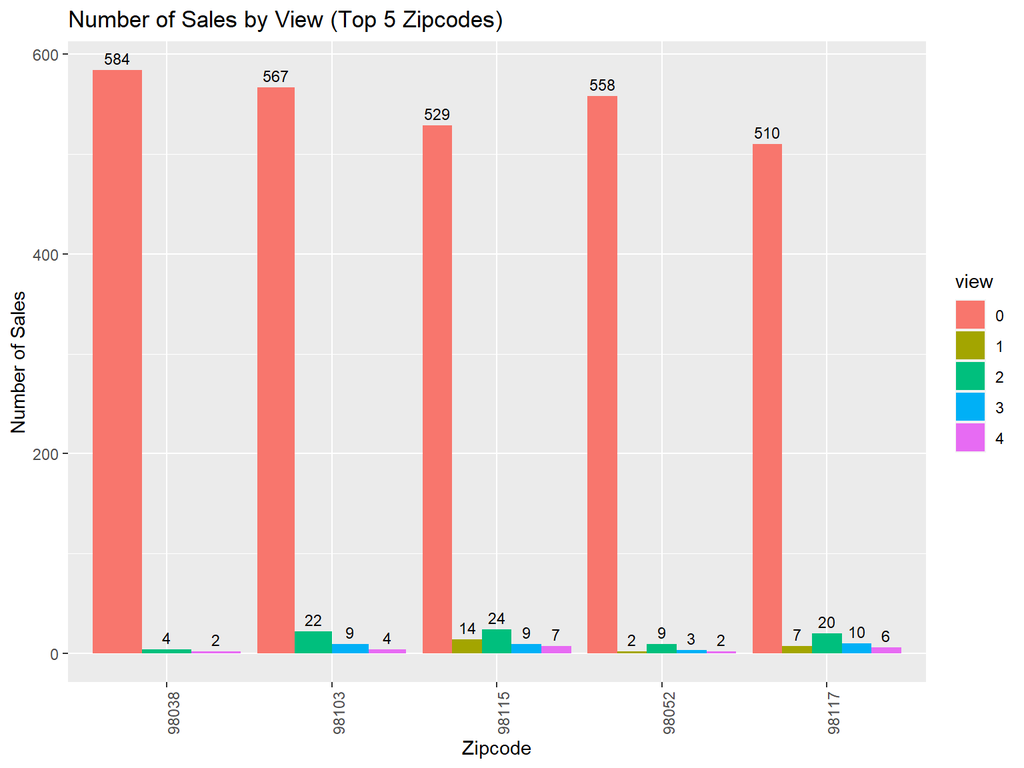

```r
ggplot(zipcode_view_counts,
       aes(x = reorder(zipcode, -count),
           y = count,
           fill = view)) +
  geom_bar(stat = "identity", position = "dodge") +
  geom_text(aes(label = count),
            position = position_dodge(width = 0.9), vjust = -0.5, size = 3) +
  labs(title = "Number of Sales by View (Top 5 Zipcodes)",
       x = "Zipcode", y = "Number of Sales") +
  theme(axis.text.x = element_text(angle = 90, hjust = 1))
```

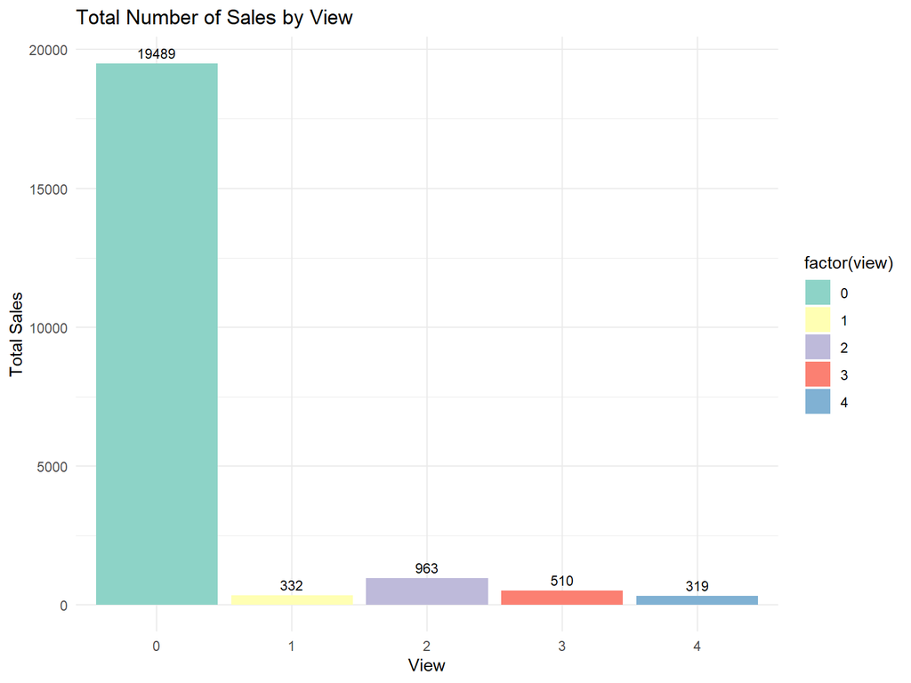

```r
ggplot(total_sales_by_view, aes(x = factor(view), y = total_sales, fill = factor(view))) +
  geom_bar(stat = "identity") +
  geom_text(aes(label = total_sales), vjust = -0.5, size = 3) +
  labs(title = "Total Number of Sales by View",
       x = "View", y = "Total Sales") +
  theme_minimal() +
  scale_fill_brewer(palette = "Set3")
```

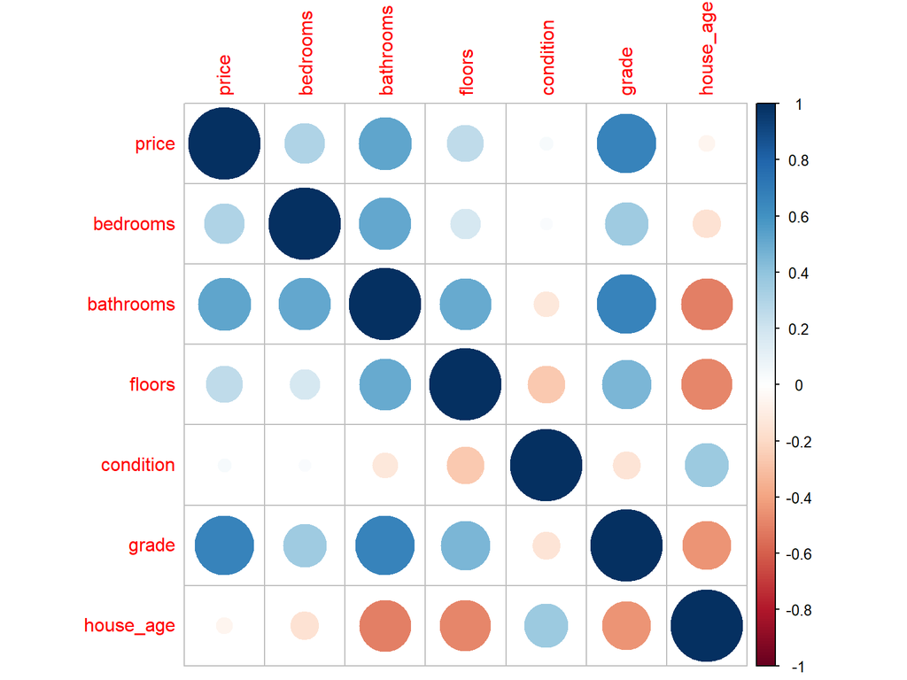

```r
cor_matrix_data <- house %>%
  select(price, bedrooms, bathrooms, floors, condition, grade, house_age) %>%
  mutate(across(everything(), as.numeric))

cor_matrix <- cor(cor_matrix_data)
corrplot(cor_matrix, method = "circle")
```

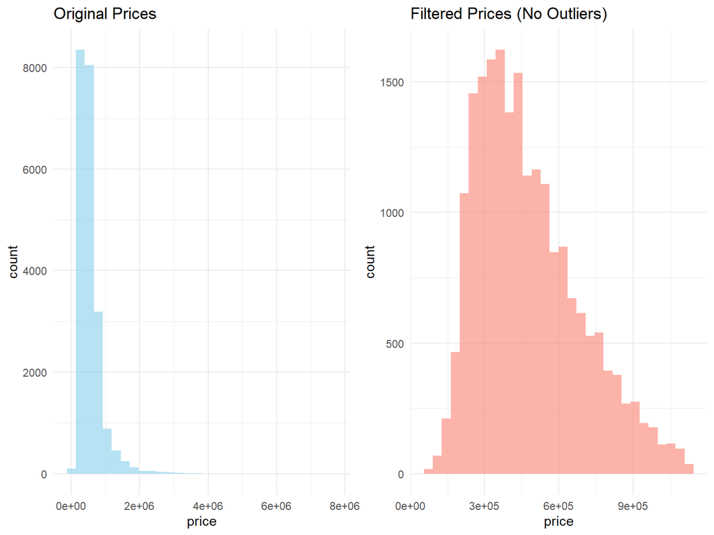

```r
p1 <- ggplot(house, aes(x = price)) +
  geom_histogram(fill = "skyblue", alpha = 0.6) +
  labs(title = "Original Prices") +
  theme_minimal()

p2 <- ggplot(data_filtered_iqr, aes(x = price)) +
  geom_histogram(fill = "salmon", alpha = 0.6) +
  labs(title = "Filtered Prices (No Outliers)") +
  theme_minimal()

grid.arrange(p1, p2,  ncol = 2)
```

# 8.ANOVA Test

1. HO: There is no significant difference in the average house price across the different levels (categories) of this factor.
2. H1: There is a significant difference in the average house price across the different levels (categories) of this factor.

```r
anova_results = aov(price ~ factor(bedrooms) + factor(bathrooms) + factor(floors) +
                      factor(waterfront) + factor(view) + factor(condition) +
                      factor(grade), data = house)

summary(anova_results)
```

```
##                       Df    Sum Sq   Mean Sq F value Pr(>F)
## factor(bedrooms)      12 3.103e+14 2.586e+13  533.57 <2e-16 ***
## factor(bathrooms)     29 7.575e+14 2.612e+13  538.96 <2e-16 ***
## factor(floors)         5 3.098e+13 6.195e+12  127.82 <2e-16 ***
## factor(waterfront)     1 1.383e+14 1.383e+14 2853.19 <2e-16 ***
## factor(view)           4 1.276e+14 3.191e+13  658.41 <2e-16 ***
## factor(condition)      4 1.748e+13 4.371e+12   90.18 <2e-16 ***
## factor(grade)         11 4.864e+14 4.422e+13  912.39 <2e-16 ***
## Residuals          21546 1.044e+15 4.847e+10
## ---
## Signif. codes:  0 '***' 0.001 '**' 0.01 '*' 0.05 '.' 0.1 ' ' 1
```

Results: Reject the null hypothesis (H0) for all factors

# 9. Machine Learning Techniques

### Set up Configuration

```r
library(doParallel)

set.seed(123)
# Split data into training (80%) and testing (20%) sets
trainIndex <- createDataPartition(house$price, p = .8, list = FALSE, times = 1)
trainData <- house[trainIndex,]
testData  <- house[-trainIndex,]

# Set up parallel processing
cores <- detectCores()
cl <- makeCluster(cores)
registerDoParallel(cl)

# Cross-validation settings
control <- trainControl(method = "cv", number = 5, allowParallel = TRUE)
```

### Train a Random Forest model

```r
rf_model <- train(price ~ ., data = trainData, method = "rf", trControl = control,
                  ntree = 50, tuneLength = 3, nodesize = 5)
rf_predictions <- predict(rf_model, testData)
rf_results <- postResample(rf_predictions, testData$price)
```

### Train an SVM model

```r
svm_model <- train(price ~ ., data = trainData, method = "svmRadial", trControl = control, tuneLength = 3)
svm_predictions <- predict(svm_model, testData)
svm_results <- postResample(svm_predictions, testData$price)
```

### Train a Linear Regression model

```r
lm_model <- train(price ~ ., data = trainData, method = "lm", trControl = control)
lm_predictions <- predict(lm_model, testData)
lm_results <- postResample(lm_predictions, testData$price)

stopCluster(cl)
registerDoSEQ()

print(rf_results)
```

```
##         RMSE     Rsquared          MAE
## 1.413322e+05 8.668827e-01 7.267166e+04
```

```r
print(svm_results)
```

```
##         RMSE     Rsquared          MAE
## 2.205501e+05 6.836166e-01 9.245400e+04
```

```r
print(lm_results)
```

```
##         RMSE     Rsquared          MAE
## 1.991836e+05 7.304947e-01 1.182295e+05
```

# 10. Final Visualization

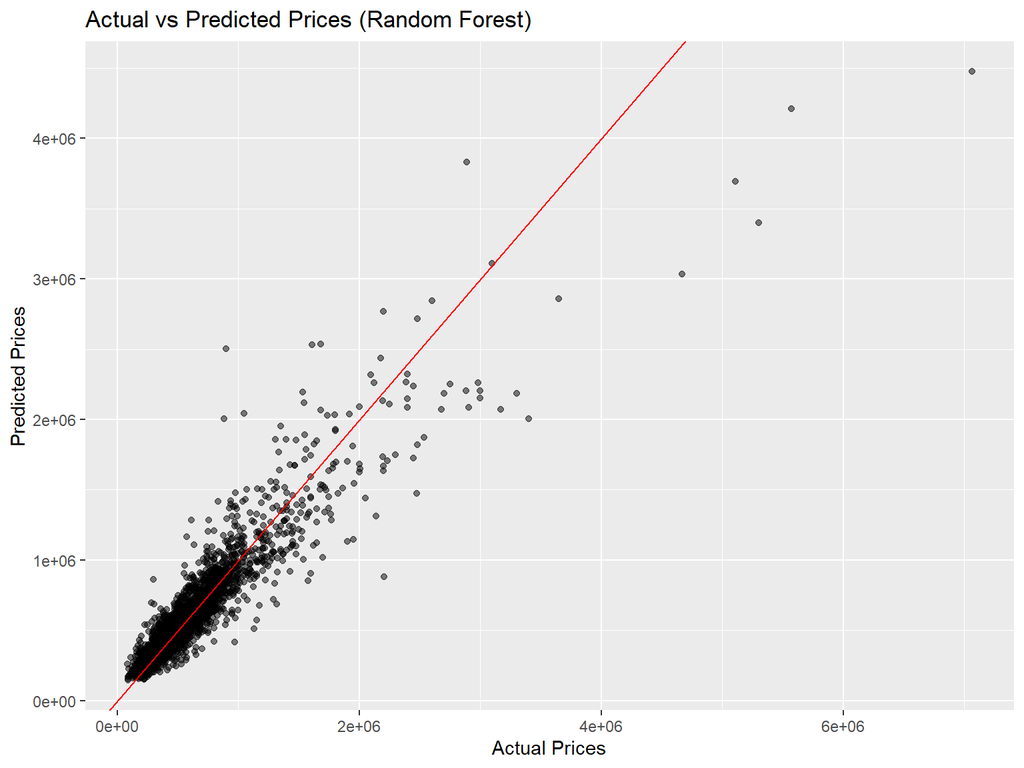

```r
ggplot() +
  geom_point(aes(x = testData$price, y = rf_predictions), alpha = 0.5) +
  geom_abline(intercept = 0, slope = 1, color = "red") +
  labs(title = "Actual vs Predicted Prices (Random Forest)", x = "Actual Prices", y = "Predicted Prices")
```

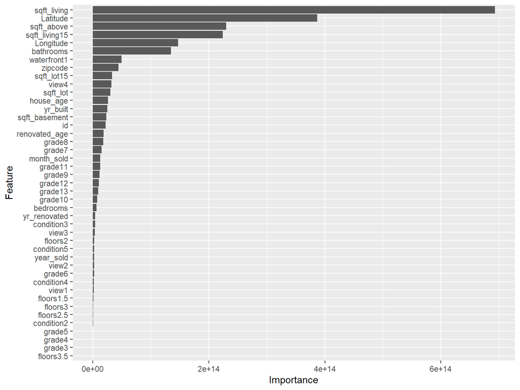

```r
rf_importance <- varImp(rf_model, scale = FALSE)
ggplot(rf_importance)
```

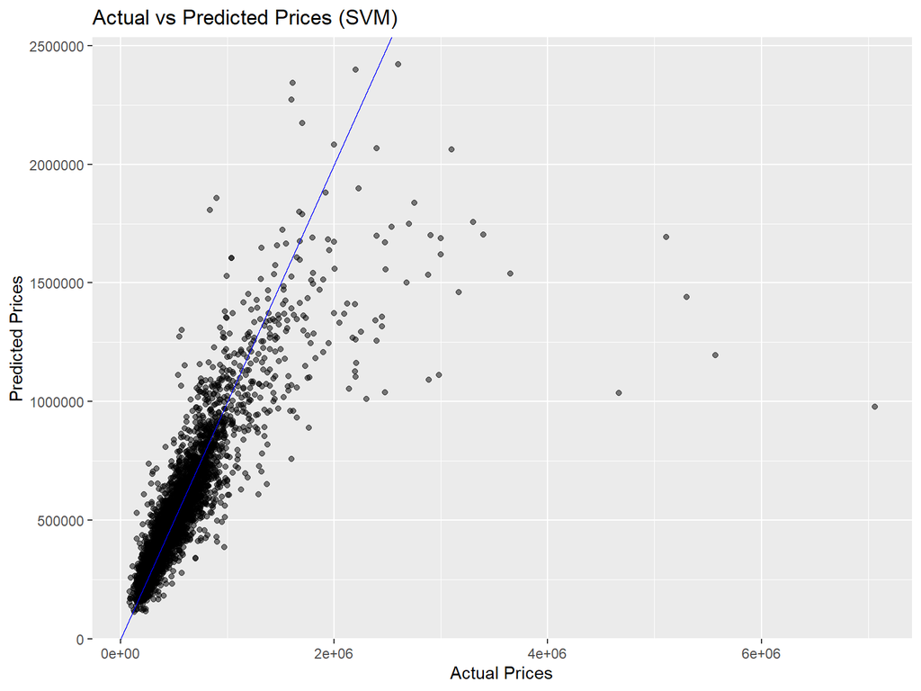

```r
ggplot() +
  geom_point(aes(x = testData$price, y = svm_predictions), alpha = 0.5) +
  geom_abline(intercept = 0, slope = 1, color = "blue") +
  labs(title = "Actual vs Predicted Prices (SVM)", x = "Actual Prices", y = "Predicted Prices")
```

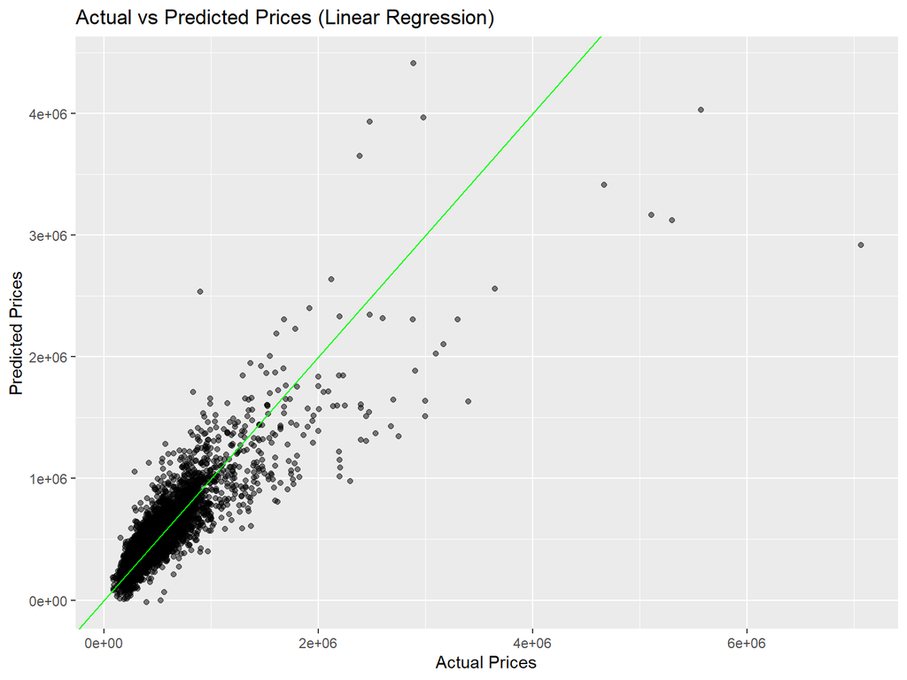

```r
ggplot() +
  geom_point(aes(x = testData$price, y = lm_predictions), alpha = 0.5) +
  geom_abline(intercept = 0, slope = 1, color = "green") +
  labs(title = "Actual vs Predicted Prices (Linear Regression)", x = "Actual Prices", y = "Predicted Prices")
```

# 11. Discussion and Implications

1. Explore different combinations of hyperparameters
2. Using Ensemble Method Technique
3. Increasing the Folds in cross-validation

# Definition for each Column

id - Unique ID for each home sold

date - Date of the home sale

price - Price of each home sold

bedrooms - Number of bedrooms

bathrooms - Number of bathrooms, where .5 accounts for a room with a toilet but no shower

sqft_living - Square footage of the apartments interior living space

sqft_lot - Square footage of the land space

floors - Number of floors

waterfront - A dummy variable for whether the apartment was overlooking the waterfront or not

view - An index from 0 to 4 of how good the view of the property was

condition - An index from 1 to 5 on the condition of the apartment,

grade - An index from 1 to 13, where 1-3 falls short of building construction and design, 7 has an average level of construction and design, and 11-13 have a high quality level of construction and design.

sqft_above - The square footage of the interior housing space that is above ground level

sqft_basement - The square footage of the interior housing space that is below ground level

yr_built - The year the house was initially built

yr_renovated - The year of the house’s last renovation

zipcode - What zipcode area the house is in

lat - Lattitude

long - Longitude

sqft_living15 - The square footage of interior housing living space for the nearest 15 neighbors

sqft_lot15 - The square footage of the land lots of the nearest 15 neighbors